# RNA-Seq

## Gene Set Enrichment Analysis with fgsea

The fgsea package does not take ensembl IDs, so the ensembl IDs are converted to gene symbols. (Biomart is currently down on the ensembl website, so the biomaRt package is not able to fetch data from their API. I am using an alternative library that is cutting my observed genes in half because it is unable to map all of the ensembl gene IDs).

```
##  [1] "DDX11L2"         "WASH7P"          "MIR1302-2HG"     "ENSG00000238009"
##  [5] "CICP27"          "ENSG00000268903" "ENSG00000269981" "ENSG00000239906"
##  [9] "ENSG00000241860" "WASH9P"          "ENSG00000292994" "RPL23AP24"
## [13] "ENSG00000290385" "ENSG00000293331" "MTND1P23"
```

Then, fgsea can be run on the differential expression analysis results. Here are most significant pathways, ranked by p<sub>adj</sub>:

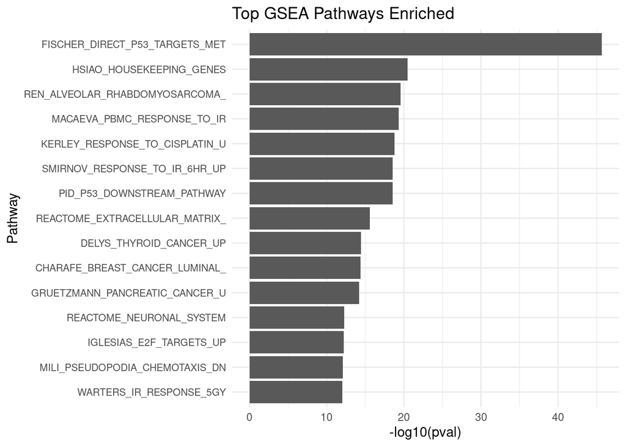

A large number of these pathways are associated with P53 signaling. The p53 pathway responds to stimuli that impact DNA replication and cell division. Similarly, there are a number of pathways that respond to cancer-related stresses. There are also enriched pathways responding to ionizing radiation (IR). Essentially, these significant pathways indicate that the experimental condition in this study looks into cancer patients and patients undergoing chemotherapy. There are a number of cancer-associated pathways that promote tumor growth as well as pathways responding to a typical cancer treatment plan.